# Risk Factor Analysis

## Outcome Variable

**Outcome Variable:** haz

## Predictor Variables

**Intervention Variable:** brthmon

**Adjustment Set:**

unadjusted

## Stratifying Variables

The analysis was stratified on these variable(s):

- agecat
- studyid
- country

## Data Summary

| agecat | studyid | country | brthmon | n_cell | n | outcome_variable |
| --- | --- | --- | --- | --- | --- | --- |
| Birth | ki0047075b-MAL-ED | BANGLADESH | 1 | 20 | 231 | haz |
| Birth | ki0047075b-MAL-ED | BANGLADESH | 2 | 23 | 231 | haz |
| Birth | ki0047075b-MAL-ED | BANGLADESH | 3 | 24 | 231 | haz |
| Birth | ki0047075b-MAL-ED | BANGLADESH | 4 | 19 | 231 | haz |
| Birth | ki0047075b-MAL-ED | BANGLADESH | 5 | 18 | 231 | haz |
| Birth | ki0047075b-MAL-ED | BANGLADESH | 6 | 8 | 231 | haz |
| Birth | ki0047075b-MAL-ED | BANGLADESH | 7 | 14 | 231 | haz |
| Birth | ki0047075b-MAL-ED | BANGLADESH | 8 | 26 | 231 | haz |
| Birth | ki0047075b-MAL-ED | BANGLADESH | 9 | 18 | 231 | haz |
| Birth | ki0047075b-MAL-ED | BANGLADESH | 10 | 21 | 231 | haz |
| Birth | ki0047075b-MAL-ED | BANGLADESH | 11 | 15 | 231 | haz |
| Birth | ki0047075b-MAL-ED | BANGLADESH | 12 | 25 | 231 | haz |
| Birth | ki0047075b-MAL-ED | BRAZIL | 1 | 5 | 65 | haz |
| Birth | ki0047075b-MAL-ED | BRAZIL | 2 | 10 | 65 | haz |
| Birth | ki0047075b-MAL-ED | BRAZIL | 3 | 7 | 65 | haz |
| Birth | ki0047075b-MAL-ED | BRAZIL | 4 | 4 | 65 | haz |
| Birth | ki0047075b-MAL-ED | BRAZIL | 5 | 2 | 65 | haz |
| Birth | ki0047075b-MAL-ED | BRAZIL | 6 | 5 | 65 | haz |
| Birth | ki0047075b-MAL-ED | BRAZIL | 7 | 6 | 65 | haz |
| Birth | ki0047075b-MAL-ED | BRAZIL | 8 | 7 | 65 | haz |
| Birth | ki0047075b-MAL-ED | BRAZIL | 9 | 6 | 65 | haz |
| Birth | ki0047075b-MAL-ED | BRAZIL | 10 | 5 | 65 | haz |
| Birth | ki0047075b-MAL-ED | BRAZIL | 11 | 4 | 65 | haz |
| Birth | ki0047075b-MAL-ED | BRAZIL | 12 | 4 | 65 | haz |
| Birth | ki0047075b-MAL-ED | INDIA | 1 | 2 | 47 | haz |
| Birth | ki0047075b-MAL-ED | INDIA | 2 | 6 | 47 | haz |
| Birth | ki0047075b-MAL-ED | INDIA | 3 | 3 | 47 | haz |
| Birth | ki0047075b-MAL-ED | INDIA | 4 | 6 | 47 | haz |
| Birth | ki0047075b-MAL-ED | INDIA | 5 | 4 | 47 | haz |
| Birth | ki0047075b-MAL-ED | INDIA | 6 | 2 | 47 | haz |

[output cut: 810 more lines]

The following strata were considered:

- agecat: 24 months, studyid: ki0047075b-MAL-ED, country: BANGLADESH
- agecat: 24 months, studyid: ki0047075b-MAL-ED, country: BRAZIL
- agecat: 24 months, studyid: ki0047075b-MAL-ED, country: INDIA
- agecat: 24 months, studyid: ki0047075b-MAL-ED, country: NEPAL
- agecat: 24 months, studyid: ki0047075b-MAL-ED, country: PERU
- agecat: 24 months, studyid: ki0047075b-MAL-ED, country: SOUTH AFRICA
- agecat: 24 months, studyid: ki0047075b-MAL-ED, country: TANZANIA, UNITED REPUBLIC OF
- agecat: 24 months, studyid: ki1000108-CMC-V-BCS-2002, country: INDIA
- agecat: 24 months, studyid: ki1000108-IRC, country: INDIA
- agecat: 24 months, studyid: ki1000109-EE, country: PAKISTAN
- agecat: 24 months, studyid: ki1017093-NIH-Birth, country: BANGLADESH
- agecat: 24 months, studyid: ki1017093b-PROVIDE, country: BANGLADESH
- agecat: 24 months, studyid: ki1066203-TanzaniaChild2, country: TANZANIA, UNITED REPUBLIC OF
- agecat: 24 months, studyid: ki1101329-Keneba, country: GAMBIA
- agecat: 24 months, studyid: ki1113344-GMS-Nepal, country: NEPAL
- agecat: 24 months, studyid: ki1114097-CMIN, country: BANGLADESH
- agecat: 24 months, studyid: ki1114097-CONTENT, country: PERU
- agecat: 24 months, studyid: ki1119695-PROBIT, country: BELARUS
- agecat: 24 months, studyid: ki1126311-ZVITAMBO, country: ZIMBABWE
- agecat: 24 months, studyid: ki1148112-LCNI-5, country: MALAWI
- agecat: 24 months, studyid: kiGH5241-JiVitA-3, country: BANGLADESH
- agecat: 24 months, studyid: kiGH5241-JiVitA-4, country: BANGLADESH
- agecat: 6 months, studyid: ki0047075b-MAL-ED, country: BANGLADESH
- agecat: 6 months, studyid: ki0047075b-MAL-ED, country: BRAZIL
- agecat: 6 months, studyid: ki0047075b-MAL-ED, country: INDIA
- agecat: 6 months, studyid: ki0047075b-MAL-ED, country: NEPAL
- agecat: 6 months, studyid: ki0047075b-MAL-ED, country: PERU
- agecat: 6 months, studyid: ki0047075b-MAL-ED, country: SOUTH AFRICA
- agecat: 6 months, studyid: ki0047075b-MAL-ED, country: TANZANIA, UNITED REPUBLIC OF
- agecat: 6 months, studyid: ki1000108-CMC-V-BCS-2002, country: INDIA
- agecat: 6 months, studyid: ki1000108-IRC, country: INDIA
- agecat: 6 months, studyid: ki1000109-EE, country: PAKISTAN
- agecat: 6 months, studyid: ki1000109-ResPak, country: PAKISTAN
- agecat: 6 months, studyid: ki1000304b-SAS-CompFeed, country: INDIA
- agecat: 6 months, studyid: ki1000304b-SAS-FoodSuppl, country: INDIA
- agecat: 6 months, studyid: ki1017093-NIH-Birth, country: BANGLADESH
- agecat: 6 months, studyid: ki1017093b-PROVIDE, country: BANGLADESH
- agecat: 6 months, studyid: ki1066203-TanzaniaChild2, country: TANZANIA, UNITED REPUBLIC OF
- agecat: 6 months, studyid: ki1101329-Keneba, country: GAMBIA
- agecat: 6 months, studyid: ki1112895-Guatemala BSC, country: GUATEMALA
- agecat: 6 months, studyid: ki1113344-GMS-Nepal, country: NEPAL
- agecat: 6 months, studyid: ki1114097-CMIN, country: BANGLADESH
- agecat: 6 months, studyid: ki1114097-CONTENT, country: PERU
- agecat: 6 months, studyid: ki1119695-PROBIT, country: BELARUS
- agecat: 6 months, studyid: ki1126311-ZVITAMBO, country: ZIMBABWE
- agecat: 6 months, studyid: ki1148112-LCNI-5, country: MALAWI
- agecat: 6 months, studyid: kiGH5241-JiVitA-3, country: BANGLADESH
- agecat: 6 months, studyid: kiGH5241-JiVitA-4, country: BANGLADESH
- agecat: Birth, studyid: ki0047075b-MAL-ED, country: BANGLADESH
- agecat: Birth, studyid: ki0047075b-MAL-ED, country: BRAZIL
- agecat: Birth, studyid: ki0047075b-MAL-ED, country: INDIA
- agecat: Birth, studyid: ki0047075b-MAL-ED, country: NEPAL
- agecat: Birth, studyid: ki0047075b-MAL-ED, country: PERU
- agecat: Birth, studyid: ki0047075b-MAL-ED, country: SOUTH AFRICA
- agecat: Birth, studyid: ki0047075b-MAL-ED, country: TANZANIA, UNITED REPUBLIC OF
- agecat: Birth, studyid: ki1000108-CMC-V-BCS-2002, country: INDIA
- agecat: Birth, studyid: ki1000108-IRC, country: INDIA
- agecat: Birth, studyid: ki1000109-EE, country: PAKISTAN
- agecat: Birth, studyid: ki1000109-ResPak, country: PAKISTAN
- agecat: Birth, studyid: ki1000304b-SAS-CompFeed, country: INDIA
- agecat: Birth, studyid: ki1017093-NIH-Birth, country: BANGLADESH
- agecat: Birth, studyid: ki1017093b-PROVIDE, country: BANGLADESH
- agecat: Birth, studyid: ki1101329-Keneba, country: GAMBIA
- agecat: Birth, studyid: ki1113344-GMS-Nepal, country: NEPAL
- agecat: Birth, studyid: ki1114097-CMIN, country: BANGLADESH
- agecat: Birth, studyid: ki1114097-CONTENT, country: PERU
- agecat: Birth, studyid: ki1119695-PROBIT, country: BELARUS
- agecat: Birth, studyid: ki1126311-ZVITAMBO, country: ZIMBABWE
- agecat: Birth, studyid: kiGH5241-JiVitA-3, country: BANGLADESH
- agecat: Birth, studyid: kiGH5241-JiVitA-4, country: BANGLADESH

### Dropped Strata

Some strata were dropped due to rare outcomes:

- agecat: Birth, studyid: ki0047075b-MAL-ED, country: BRAZIL
- agecat: Birth, studyid: ki0047075b-MAL-ED, country: INDIA
- agecat: Birth, studyid: ki0047075b-MAL-ED, country: NEPAL
- agecat: Birth, studyid: ki0047075b-MAL-ED, country: SOUTH AFRICA
- agecat: Birth, studyid: ki1000108-CMC-V-BCS-2002, country: INDIA
- agecat: Birth, studyid: ki1000109-EE, country: PAKISTAN
- agecat: Birth, studyid: ki1000109-ResPak, country: PAKISTAN
- agecat: Birth, studyid: ki1113344-GMS-Nepal, country: NEPAL
- agecat: Birth, studyid: ki1114097-CMIN, country: BANGLADESH
- agecat: Birth, studyid: ki1114097-CONTENT, country: PERU
- agecat: Birth, studyid: kiGH5241-JiVitA-4, country: BANGLADESH
- agecat: 6 months, studyid: ki1000109-EE, country: PAKISTAN
- agecat: 6 months, studyid: ki1000109-ResPak, country: PAKISTAN
- agecat: 6 months, studyid: ki1000304b-SAS-FoodSuppl, country: INDIA
- agecat: 6 months, studyid: ki1113344-GMS-Nepal, country: NEPAL
- agecat: 6 months, studyid: kiGH5241-JiVitA-4, country: BANGLADESH
- agecat: 24 months, studyid: ki1000109-EE, country: PAKISTAN
- agecat: 24 months, studyid: ki1066203-TanzaniaChild2, country: TANZANIA, UNITED REPUBLIC OF
- agecat: 24 months, studyid: ki1113344-GMS-Nepal, country: NEPAL
- agecat: 24 months, studyid: kiGH5241-JiVitA-4, country: BANGLADESH

## Methods Detail

We’re interested in the causal parameters $E[Y_a]$ for all values of $a \in \mathcal{A}$. These parameters represent the mean outcome if, possibly contrary to fact, we intervened to set all units to have $A=a$. Under the randomization and positivity assumptions, these are identified by the statistical parameters $\psi_a=E_W[E_{Y|A,W}(Y|A=a,W)]$. In addition, we’re interested in the mean of $Y$, $E[Y]$ under no intervention (the observed mean). We will estimate these parameters by using SuperLearner to fit the relevant likelihood factors – $E_{Y|A,W}(Y|A=a,W)$ and $p(A=a|W)$, and then updating our likelihood fit using a joint TMLE.

For unadjusted analyses ($W=\{\}$), initial likelihoods were estimated using Lrnr_glm to estimate the simple $E(Y|A)$ and Lrnr_mean to estimate $p(A)$. For adjusted analyses, a small library containing Lrnr_glmnet, Lrnr_xgboost, and Lrnr_mean was used.

Having estimated these parameters, we will then use the delta method to estimate relative risks and attributable risks relative to a prespecified baseline level of $A$.

# Results Detail

## Results Plots

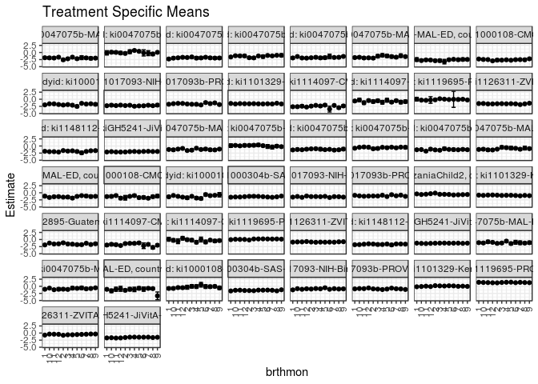

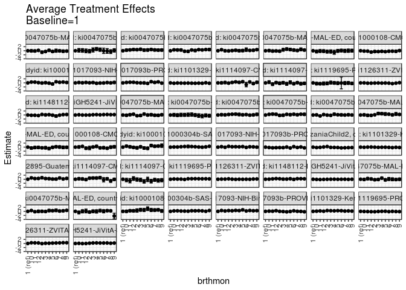

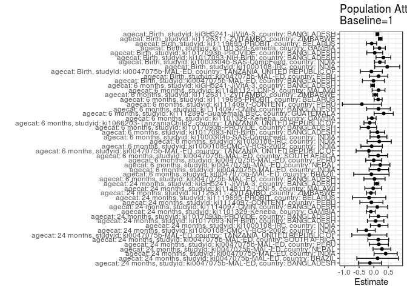

## Results Table

### Parameter: TSM

| agecat | studyid | country | intervention_level | baseline_level | estimate | ci_lower | ci_upper |
| --- | --- | --- | --- | --- | --- | --- | --- |
| Birth | ki0047075b-MAL-ED | BANGLADESH | 1 | NA | -1.1075000 | -1.4978140 | -0.7171860 |
| Birth | ki0047075b-MAL-ED | BANGLADESH | 2 | NA | -1.3482609 | -1.7601227 | -0.9363990 |
| Birth | ki0047075b-MAL-ED | BANGLADESH | 3 | NA | -1.2345833 | -1.6339311 | -0.8352355 |
| Birth | ki0047075b-MAL-ED | BANGLADESH | 4 | NA | -0.5626316 | -0.9338618 | -0.1914013 |
| Birth | ki0047075b-MAL-ED | BANGLADESH | 5 | NA | -1.4155556 | -1.9277899 | -0.9033212 |
| Birth | ki0047075b-MAL-ED | BANGLADESH | 6 | NA | -0.9850000 | -1.6643530 | -0.3056470 |
| Birth | ki0047075b-MAL-ED | BANGLADESH | 7 | NA | -1.1464286 | -1.7919695 | -0.5008876 |
| Birth | ki0047075b-MAL-ED | BANGLADESH | 8 | NA | -1.2623077 | -1.6681956 | -0.8564198 |
| Birth | ki0047075b-MAL-ED | BANGLADESH | 9 | NA | -1.1161111 | -1.6499711 | -0.5822511 |
| Birth | ki0047075b-MAL-ED | BANGLADESH | 10 | NA | -1.2219048 | -1.6052781 | -0.8385314 |
| Birth | ki0047075b-MAL-ED | BANGLADESH | 11 | NA | -0.8020000 | -1.3165147 | -0.2874853 |
| Birth | ki0047075b-MAL-ED | BANGLADESH | 12 | NA | -0.9916000 | -1.3962342 | -0.5869658 |
| Birth | ki0047075b-MAL-ED | PERU | 1 | NA | -1.0476667 | -1.3885098 | -0.7068235 |
| Birth | ki0047075b-MAL-ED | PERU | 2 | NA | -1.0205556 | -1.4494133 | -0.5916978 |
| Birth | ki0047075b-MAL-ED | PERU | 3 | NA | -1.1055000 | -1.4587186 | -0.7522814 |
| Birth | ki0047075b-MAL-ED | PERU | 4 | NA | -0.6600000 | -1.2168652 | -0.1031348 |
| Birth | ki0047075b-MAL-ED | PERU | 5 | NA | -0.7268182 | -1.1317595 | -0.3218768 |
| Birth | ki0047075b-MAL-ED | PERU | 6 | NA | -0.5654545 | -1.1606928 | 0.0297837 |
| Birth | ki0047075b-MAL-ED | PERU | 7 | NA | -0.8884211 | -1.3124533 | -0.4643888 |
| Birth | ki0047075b-MAL-ED | PERU | 8 | NA | -0.7825000 | -1.1500122 | -0.4149878 |
| Birth | ki0047075b-MAL-ED | PERU | 9 | NA | -0.5463158 | -0.7856721 | -0.3069594 |
| Birth | ki0047075b-MAL-ED | PERU | 10 | NA | -0.6423810 | -0.9048824 | -0.3798795 |
| Birth | ki0047075b-MAL-ED | PERU | 11 | NA | -1.2125000 | -1.5501638 | -0.8748362 |
| Birth | ki0047075b-MAL-ED | PERU | 12 | NA | -1.0321429 | -1.5719969 | -0.4922888 |
| Birth | ki0047075b-MAL-ED | TANZANIA, UNITED REPUBLIC OF | 1 | NA | -1.0740000 | -1.4137403 | -0.7342597 |
| Birth | ki0047075b-MAL-ED | TANZANIA, UNITED REPUBLIC OF | 2 | NA | -1.4187500 | -1.8520366 | -0.9854634 |
| Birth | ki0047075b-MAL-ED | TANZANIA, UNITED REPUBLIC OF | 3 | NA | -1.0400000 | -1.6642136 | -0.4157864 |
| Birth | ki0047075b-MAL-ED | TANZANIA, UNITED REPUBLIC OF | 4 | NA | -1.1012500 | -1.8872554 | -0.3152446 |
| Birth | ki0047075b-MAL-ED | TANZANIA, UNITED REPUBLIC OF | 5 | NA | -0.7100000 | -1.2909595 | -0.1290405 |
| Birth | ki0047075b-MAL-ED | TANZANIA, UNITED REPUBLIC OF | 6 | NA | -1.0118182 | -1.7598448 | -0.2637916 |

[output cut: 570 more lines]

### Parameter: E(Y)

| agecat | studyid | country | intervention_level | baseline_level | estimate | ci_lower | ci_upper |
| --- | --- | --- | --- | --- | --- | --- | --- |
| Birth | ki0047075b-MAL-ED | BANGLADESH | NA | NA | -1.1180952 | -1.2525408 | -0.9836496 |
| Birth | ki0047075b-MAL-ED | PERU | NA | NA | -0.8827897 | -1.0001058 | -0.7654736 |
| Birth | ki0047075b-MAL-ED | TANZANIA, UNITED REPUBLIC OF | NA | NA | -1.1556000 | -1.3655361 | -0.9456639 |
| Birth | ki1000108-IRC | INDIA | NA | NA | -0.3080412 | -0.4687931 | -0.1472894 |
| Birth | ki1000304b-SAS-CompFeed | INDIA | NA | NA | -1.4314217 | -1.5099245 | -1.3529189 |
| Birth | ki1017093-NIH-Birth | BANGLADESH | NA | NA | -0.9310197 | -1.0197391 | -0.8423003 |
| Birth | ki1017093b-PROVIDE | BANGLADESH | NA | NA | -0.8851020 | -0.9601332 | -0.8100709 |
| Birth | ki1101329-Keneba | GAMBIA | NA | NA | 0.0308036 | -0.0328378 | 0.0944451 |
| Birth | ki1119695-PROBIT | BELARUS | NA | NA | 1.3269446 | 1.1683850 | 1.4855041 |
| Birth | ki1126311-ZVITAMBO | ZIMBABWE | NA | NA | -0.5002724 | -0.5208163 | -0.4797285 |
| Birth | kiGH5241-JiVitA-3 | BANGLADESH | NA | NA | -1.5894148 | -1.6086362 | -1.5701935 |
| 6 months | ki0047075b-MAL-ED | BANGLADESH | NA | NA | -1.2049931 | -1.3222136 | -1.0877726 |
| 6 months | ki0047075b-MAL-ED | BRAZIL | NA | NA | 0.0475758 | -0.0963508 | 0.1915023 |
| 6 months | ki0047075b-MAL-ED | INDIA | NA | NA | -1.2115254 | -1.3298727 | -1.0931782 |
| 6 months | ki0047075b-MAL-ED | NEPAL | NA | NA | -0.5615819 | -0.6741832 | -0.4489807 |
| 6 months | ki0047075b-MAL-ED | PERU | NA | NA | -1.3236661 | -1.4316775 | -1.2156546 |
| 6 months | ki0047075b-MAL-ED | SOUTH AFRICA | NA | NA | -1.0633202 | -1.1909180 | -0.9357224 |
| 6 months | ki0047075b-MAL-ED | TANZANIA, UNITED REPUBLIC OF | NA | NA | -1.3687449 | -1.4907629 | -1.2467270 |
| 6 months | ki1000108-CMC-V-BCS-2002 | INDIA | NA | NA | -1.4234508 | -1.5645974 | -1.2823042 |
| 6 months | ki1000108-IRC | INDIA | NA | NA | -1.2344062 | -1.3658524 | -1.1029600 |
| 6 months | ki1000304b-SAS-CompFeed | INDIA | NA | NA | -1.4018563 | -1.4810585 | -1.3226541 |
| 6 months | ki1017093-NIH-Birth | BANGLADESH | NA | NA | -1.4073821 | -1.4960598 | -1.3187043 |
| 6 months | ki1017093b-PROVIDE | BANGLADESH | NA | NA | -1.0916915 | -1.1661176 | -1.0172654 |
| 6 months | ki1066203-TanzaniaChild2 | TANZANIA, UNITED REPUBLIC OF | NA | NA | -0.5434389 | -0.5924056 | -0.4944722 |
| 6 months | ki1101329-Keneba | GAMBIA | NA | NA | -0.9041369 | -0.9513363 | -0.8569376 |
| 6 months | ki1112895-Guatemala BSC | GUATEMALA | NA | NA | -1.5619008 | -1.6727702 | -1.4510313 |
| 6 months | ki1114097-CMIN | BANGLADESH | NA | NA | -1.7844376 | -1.9222926 | -1.6465825 |
| 6 months | ki1114097-CONTENT | PERU | NA | NA | -0.3139217 | -0.4868486 | -0.1409948 |
| 6 months | ki1119695-PROBIT | BELARUS | NA | NA | 0.1069986 | 0.0122286 | 0.2017686 |
| 6 months | ki1126311-ZVITAMBO | ZIMBABWE | NA | NA | -0.8679450 | -0.8935071 | -0.8423828 |
| 6 months | ki1148112-LCNI-5 | MALAWI | NA | NA | -1.6601907 | -1.7297701 | -1.5906113 |
| 6 months | kiGH5241-JiVitA-3 | BANGLADESH | NA | NA | -1.3130932 | -1.3362359 | -1.2899505 |
| 24 months | ki0047075b-MAL-ED | BANGLADESH | NA | NA | -1.9783962 | -2.1050210 | -1.8517715 |
| 24 months | ki0047075b-MAL-ED | BRAZIL | NA | NA | 0.0061144 | -0.1625850 | 0.1748138 |
| 24 months | ki0047075b-MAL-ED | INDIA | NA | NA | -1.8861894 | -2.0110006 | -1.7613783 |
| 24 months | ki0047075b-MAL-ED | NEPAL | NA | NA | -1.3075877 | -1.4270718 | -1.1881037 |
| 24 months | ki0047075b-MAL-ED | PERU | NA | NA | -1.7524710 | -1.8736426 | -1.6312994 |
| 24 months | ki0047075b-MAL-ED | SOUTH AFRICA | NA | NA | -1.6450595 | -1.7797240 | -1.5103950 |
| 24 months | ki0047075b-MAL-ED | TANZANIA, UNITED REPUBLIC OF | NA | NA | -2.6455607 | -2.7807256 | -2.5103959 |
| 24 months | ki1000108-CMC-V-BCS-2002 | INDIA | NA | NA | -2.5588679 | -2.6583730 | -2.4593629 |
| 24 months | ki1000108-IRC | INDIA | NA | NA | -1.7987775 | -1.8923914 | -1.7051636 |
| 24 months | ki1017093-NIH-Birth | BANGLADESH | NA | NA | -2.2190579 | -2.3217459 | -2.1163699 |
| 24 months | ki1017093b-PROVIDE | BANGLADESH | NA | NA | -1.6024221 | -1.6857420 | -1.5191023 |
| 24 months | ki1101329-Keneba | GAMBIA | NA | NA | -1.5774356 | -1.6272400 | -1.5276311 |
| 24 months | ki1114097-CMIN | BANGLADESH | NA | NA | -2.5109504 | -2.6361514 | -2.3857494 |
| 24 months | ki1114097-CONTENT | PERU | NA | NA | -0.6962195 | -0.8674103 | -0.5250287 |
| 24 months | ki1119695-PROBIT | BELARUS | NA | NA | -0.1314048 | -0.4282725 | 0.1654630 |
| 24 months | ki1126311-ZVITAMBO | ZIMBABWE | NA | NA | -1.6055701 | -1.6625562 | -1.5485840 |
| 24 months | ki1148112-LCNI-5 | MALAWI | NA | NA | -1.8861485 | -1.9671802 | -1.8051169 |
| 24 months | kiGH5241-JiVitA-3 | BANGLADESH | NA | NA | -2.0136481 | -2.0413552 | -1.9859409 |

### Parameter: ATE

| agecat | studyid | country | intervention_level | baseline_level | estimate | ci_lower | ci_upper |
| --- | --- | --- | --- | --- | --- | --- | --- |
| Birth | ki0047075b-MAL-ED | BANGLADESH | 1 | 1 | 0.0000000 | 0.0000000 | 0.0000000 |
| Birth | ki0047075b-MAL-ED | BANGLADESH | 2 | 1 | -0.2407609 | -0.8081895 | 0.3266677 |
| Birth | ki0047075b-MAL-ED | BANGLADESH | 3 | 1 | -0.1270833 | -0.6854951 | 0.4313284 |
| Birth | ki0047075b-MAL-ED | BANGLADESH | 4 | 1 | 0.5448684 | 0.0062063 | 1.0835306 |
| Birth | ki0047075b-MAL-ED | BANGLADESH | 5 | 1 | -0.3080556 | -0.9520502 | 0.3359391 |
| Birth | ki0047075b-MAL-ED | BANGLADESH | 6 | 1 | 0.1225000 | -0.6609957 | 0.9059957 |
| Birth | ki0047075b-MAL-ED | BANGLADESH | 7 | 1 | -0.0389286 | -0.7932946 | 0.7154375 |
| Birth | ki0047075b-MAL-ED | BANGLADESH | 8 | 1 | -0.1548077 | -0.7179151 | 0.4082997 |
| Birth | ki0047075b-MAL-ED | BANGLADESH | 9 | 1 | -0.0086111 | -0.6699367 | 0.6527145 |
| Birth | ki0047075b-MAL-ED | BANGLADESH | 10 | 1 | -0.1144048 | -0.6615064 | 0.4326968 |
| Birth | ki0047075b-MAL-ED | BANGLADESH | 11 | 1 | 0.3055000 | -0.3403099 | 0.9513099 |
| Birth | ki0047075b-MAL-ED | BANGLADESH | 12 | 1 | 0.1159000 | -0.4463045 | 0.6781045 |
| Birth | ki0047075b-MAL-ED | PERU | 1 | 1 | 0.0000000 | 0.0000000 | 0.0000000 |
| Birth | ki0047075b-MAL-ED | PERU | 2 | 1 | 0.0271111 | -0.5206964 | 0.5749186 |
| Birth | ki0047075b-MAL-ED | PERU | 3 | 1 | -0.0578333 | -0.5486871 | 0.4330205 |
| Birth | ki0047075b-MAL-ED | PERU | 4 | 1 | 0.3876667 | -0.2652291 | 1.0405624 |
| Birth | ki0047075b-MAL-ED | PERU | 5 | 1 | 0.3208485 | -0.2084449 | 0.8501419 |
| Birth | ki0047075b-MAL-ED | PERU | 6 | 1 | 0.4822121 | -0.2037052 | 1.1681295 |
| Birth | ki0047075b-MAL-ED | PERU | 7 | 1 | 0.1592456 | -0.3847925 | 0.7032837 |
| Birth | ki0047075b-MAL-ED | PERU | 8 | 1 | 0.2651667 | -0.2360711 | 0.7664044 |
| Birth | ki0047075b-MAL-ED | PERU | 9 | 1 | 0.5013509 | 0.0848590 | 0.9178428 |
| Birth | ki0047075b-MAL-ED | PERU | 10 | 1 | 0.4052857 | -0.0249247 | 0.8354962 |
| Birth | ki0047075b-MAL-ED | PERU | 11 | 1 | -0.1648333 | -0.6446154 | 0.3149488 |
| Birth | ki0047075b-MAL-ED | PERU | 12 | 1 | 0.0155238 | -0.6229246 | 0.6539723 |
| Birth | ki0047075b-MAL-ED | TANZANIA, UNITED REPUBLIC OF | 1 | 1 | 0.0000000 | 0.0000000 | 0.0000000 |
| Birth | ki0047075b-MAL-ED | TANZANIA, UNITED REPUBLIC OF | 2 | 1 | -0.3447500 | -0.8953503 | 0.2058503 |
| Birth | ki0047075b-MAL-ED | TANZANIA, UNITED REPUBLIC OF | 3 | 1 | 0.0340000 | -0.6766800 | 0.7446800 |
| Birth | ki0047075b-MAL-ED | TANZANIA, UNITED REPUBLIC OF | 4 | 1 | -0.0272500 | -0.8835373 | 0.8290373 |
| Birth | ki0047075b-MAL-ED | TANZANIA, UNITED REPUBLIC OF | 5 | 1 | 0.3640000 | -0.3090063 | 1.0370063 |
| Birth | ki0047075b-MAL-ED | TANZANIA, UNITED REPUBLIC OF | 6 | 1 | 0.0621818 | -0.7593821 | 0.8837457 |

[output cut: 570 more lines]

### Parameter: PAR

| agecat | studyid | country | intervention_level | baseline_level | estimate | ci_lower | ci_upper |
| --- | --- | --- | --- | --- | --- | --- | --- |
| Birth | ki0047075b-MAL-ED | BANGLADESH | 1 | NA | -0.0105952 | -0.3901220 | 0.3689315 |
| Birth | ki0047075b-MAL-ED | PERU | 1 | NA | 0.1648770 | -0.1513841 | 0.4811380 |
| Birth | ki0047075b-MAL-ED | TANZANIA, UNITED REPUBLIC OF | 1 | NA | -0.0816000 | -0.4571381 | 0.2939381 |
| Birth | ki1000108-IRC | INDIA | 1 | NA | 0.4605302 | 0.0320342 | 0.8890262 |
| Birth | ki1000304b-SAS-CompFeed | INDIA | 1 | NA | 0.2078806 | 0.0272573 | 0.3885039 |
| Birth | ki1017093-NIH-Birth | BANGLADESH | 1 | NA | 0.3302660 | 0.0764159 | 0.5841161 |
| Birth | ki1017093b-PROVIDE | BANGLADESH | 1 | NA | 0.0322313 | -0.2406375 | 0.3051001 |
| Birth | ki1101329-Keneba | GAMBIA | 1 | NA | 0.1949754 | -0.0073393 | 0.3972902 |
| Birth | ki1119695-PROBIT | BELARUS | 1 | NA | -0.0740300 | -0.2475743 | 0.0995143 |
| Birth | ki1126311-ZVITAMBO | ZIMBABWE | 1 | NA | 0.2215369 | 0.1591179 | 0.2839560 |
| Birth | kiGH5241-JiVitA-3 | BANGLADESH | 1 | NA | 0.1252224 | 0.0769416 | 0.1735033 |
| 6 months | ki0047075b-MAL-ED | BANGLADESH | 1 | NA | 0.0251921 | -0.3373398 | 0.3877240 |
| 6 months | ki0047075b-MAL-ED | BRAZIL | 1 | NA | -0.0823131 | -0.6893935 | 0.5247673 |
| 6 months | ki0047075b-MAL-ED | INDIA | 1 | NA | 0.1753167 | -0.1614617 | 0.5120951 |
| 6 months | ki0047075b-MAL-ED | NEPAL | 1 | NA | 0.2215847 | -0.1108575 | 0.5540270 |
| 6 months | ki0047075b-MAL-ED | PERU | 1 | NA | -0.0014292 | -0.2769260 | 0.2740675 |
| 6 months | ki0047075b-MAL-ED | SOUTH AFRICA | 1 | NA | 0.1511096 | -0.1660634 | 0.4682826 |
| 6 months | ki0047075b-MAL-ED | TANZANIA, UNITED REPUBLIC OF | 1 | NA | -0.1684116 | -0.6068106 | 0.2699874 |
| 6 months | ki1000108-CMC-V-BCS-2002 | INDIA | 1 | NA | -0.0737939 | -0.4421570 | 0.2945692 |
| 6 months | ki1000108-IRC | INDIA | 1 | NA | 0.1868657 | -0.2279610 | 0.6016924 |
| 6 months | ki1000304b-SAS-CompFeed | INDIA | 1 | NA | 0.1606724 | -0.1294260 | 0.4507709 |
| 6 months | ki1017093-NIH-Birth | BANGLADESH | 1 | NA | 0.1243808 | -0.1259152 | 0.3746767 |
| 6 months | ki1017093b-PROVIDE | BANGLADESH | 1 | NA | -0.1855010 | -0.4683571 | 0.0973551 |
| 6 months | ki1066203-TanzaniaChild2 | TANZANIA, UNITED REPUBLIC OF | 1 | NA | -0.1388145 | -0.3362391 | 0.0586102 |
| 6 months | ki1101329-Keneba | GAMBIA | 1 | NA | -0.0655480 | -0.2120240 | 0.0809279 |
| 6 months | ki1112895-Guatemala BSC | GUATEMALA | 1 | NA | 0.3408968 | 0.0129613 | 0.6688324 |
| 6 months | ki1114097-CMIN | BANGLADESH | 1 | NA | 0.1607547 | -0.2436720 | 0.5651814 |
| 6 months | ki1114097-CONTENT | PERU | 1 | NA | -0.4085217 | -1.0774062 | 0.2603628 |
| 6 months | ki1119695-PROBIT | BELARUS | 1 | NA | 0.1503644 | 0.0135262 | 0.2872026 |
| 6 months | ki1126311-ZVITAMBO | ZIMBABWE | 1 | NA | 0.0518244 | -0.0278712 | 0.1315200 |
| 6 months | ki1148112-LCNI-5 | MALAWI | 1 | NA | 0.1640740 | -0.0558159 | 0.3839639 |
| 6 months | kiGH5241-JiVitA-3 | BANGLADESH | 1 | NA | -0.0402052 | -0.1040227 | 0.0236124 |
| 24 months | ki0047075b-MAL-ED | BANGLADESH | 1 | NA | -0.1312534 | -0.5302948 | 0.2677880 |
| 24 months | ki0047075b-MAL-ED | BRAZIL | 1 | NA | 0.1321144 | -0.5793775 | 0.8436063 |
| 24 months | ki0047075b-MAL-ED | INDIA | 1 | NA | 0.4074948 | 0.0100951 | 0.8048945 |
| 24 months | ki0047075b-MAL-ED | NEPAL | 1 | NA | 0.2800439 | -0.0254721 | 0.5855599 |
| 24 months | ki0047075b-MAL-ED | PERU | 1 | NA | 0.1730290 | -0.1556230 | 0.5016810 |
| 24 months | ki0047075b-MAL-ED | SOUTH AFRICA | 1 | NA | 0.1546464 | -0.2019052 | 0.5111979 |
| 24 months | ki0047075b-MAL-ED | TANZANIA, UNITED REPUBLIC OF | 1 | NA | -0.1525607 | -0.7545152 | 0.4493937 |
| 24 months | ki1000108-CMC-V-BCS-2002 | INDIA | 1 | NA | -0.2572993 | -0.5645991 | 0.0500005 |
| 24 months | ki1000108-IRC | INDIA | 1 | NA | 0.1842050 | -0.1163562 | 0.4847661 |
| 24 months | ki1017093-NIH-Birth | BANGLADESH | 1 | NA | 0.0642754 | -0.2184618 | 0.3470127 |
| 24 months | ki1017093b-PROVIDE | BANGLADESH | 1 | NA | 0.1575779 | -0.1486216 | 0.4637773 |
| 24 months | ki1101329-Keneba | GAMBIA | 1 | NA | -0.1001061 | -0.2503374 | 0.0501252 |
| 24 months | ki1114097-CMIN | BANGLADESH | 1 | NA | 0.1203957 | -0.2284061 | 0.4691976 |
| 24 months | ki1114097-CONTENT | PERU | 1 | NA | -0.0819338 | -0.4767252 | 0.3128576 |
| 24 months | ki1119695-PROBIT | BELARUS | 1 | NA | -0.1585080 | -0.7306862 | 0.4136702 |
| 24 months | ki1126311-ZVITAMBO | ZIMBABWE | 1 | NA | -0.0967017 | -0.2496145 | 0.0562110 |
| 24 months | ki1148112-LCNI-5 | MALAWI | 1 | NA | -0.0205388 | -0.3065594 | 0.2654818 |
| 24 months | kiGH5241-JiVitA-3 | BANGLADESH | 1 | NA | 0.0980787 | 0.0224325 | 0.1737248 |